# Single-Cell Omics Research and Education

SCORE #8: Annotating a Xenium Dataset

Jonathan Nelson

24 November 2025

```r
library("dplyr")
library("Seurat")
library("knitr")
library("ggplot2")
library("BiocManager")
library("here")
#BiocManager::install("EnhancedVolcano")
library("EnhancedVolcano") #volcano plot
#install.packages('DESeq2') #for DEG
library("DESeq2")
library("tidyverse") #tidy up data
library("styler") #tidy up data
library("scCustomize") #for color scales)
library("qs") #for color scales)


if (!require("kableExtra")) {install.packages("kableExtra"); require("kableExtra")} # for color brewer
if (!require("RColorBrewer")) {install.packages("RColorBrewer"); require("RColorBrewer")} # for color brewer
if (!require("sctransform")) {install.packages("sctransform"); require("sctransform")} # for data normalization
if (!require("glmGamPoi")) {BiocManager::install('glmGamPoi'); require("glmGamPoi")} # for data normalization, sctransform
if (!require("cowplot")) {install.packages("cowplot"); require("cowplot")} # for figure layout
if (!require("patchwork")) {install.packages("patchwork"); require("patchwork")} # for figure patching
if (!require("openxlsx")) {install.packages("openxlsx"); require("openxlsx")} # to save .xlsx files

# install.packages("styler")

set.seed(12345)
# here()
```

# 1 Welcome

[figure not shown]

Welcome to the **Single-Cell Omics Research and Education Club**!

If this is your time to the club, **I want to extend and extra-special welcome to you!**

I’m **Jonathan Nelson**, an Assistant Professor at the University of Southern California. I’m a **wet** scientist turned **wet+dry** scientist. I’ve been working with **single-cell RNAseq data** for the past **5 years** and I’m excited to share what I’ve learned with you.

## 1.1 SCORE Values

### 1.1.1 **Learning**

We believe that bioinformatics is a constantly evolving field, and that ongoing learning and professional development is essential to staying up-to-date. We encourage members to share their knowledge and experiences with each other, and to seek out opportunities for continued learning.

### 1.1.2 **Accessibility**

We believe that access to bioinformatics support should be available to everyone. We strive to create a welcoming and inclusive environment where all members can feel comfortable asking for help and contributing to the group.

### 1.1.3 **Collaboration**

We believe that working together is key to achieving success in bioinformatics. We value the diversity of perspectives and backgrounds that each member brings, and we encourage open communication and the sharing of ideas.

### 1.1.4 **Integrity**

We believe in conducting ourselves with honesty and professionalism in all our interactions. We hold ourselves to high ethical standards and respect the privacy and confidentiality of all members.

### 1.1.5 **Empathy**

We believe in approaching each other with empathy and kindness. We understand that bioinformatics can be a challenging and sometimes frustrating field, and we strive to support each other through these difficulties.

## 1.2 Context and Expectations

I know a lot of this has been going on in the background for everyone and I wanted to bring it to the forefront. **My expectation** is that we have **4-6 more meetings** about spatial transcriptomics…and then we’ll re-evaluate.

Email me you would like me to add anyone: **j.nelson@med.usc.edu**

Today’s code (**this html file**) will be posted to the SCORE website (https://usckrc.github.io/website/score.html)

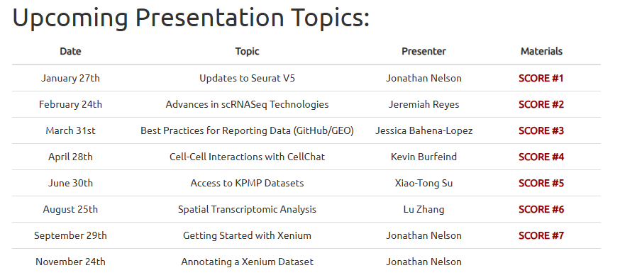

# 2 The Agenda!

[figure not shown]

## 2.1 Music and Memes

## 2.2 Main Theme: **Xenium Annotation**

# 3 Music and Memes

## 3.1 This Months Coding Music

### 3.1.1 **Jamie XX**: In Colour

https://open.spotify.com/album/04Duapg2mNlVykd895xcfZ?si=v_FC-0PXRd607eJWho2V4w

[figure not shown]

### 3.1.2 SeeSaw **Hits**

## 3.2 The Memes

### 3.2.1 Meme 1/2: The **REAL** Nobel Prize

[figure not shown]

### 3.2.2 Meme 1: **THE** Pain

[figure not shown]

### 3.2.3 Meme 2: **INSIGHT**

[figure not shown]

# 4 Main Theme: **Xenium Annotation**

## 4.1 **Series** on Spatial Transcriptomics

[figure not shown]

#### 4.1.0.1 See SCORE #6 for **Background** on Spatial Transcriptomics

https://usckrc.github.io/website/SCORE_6__LZ_ST_ppt.pdf

#### 4.1.0.2 See SCORE #7 for **Starting with a Xenium Dataset**

https://usckrc.github.io/website/SCORE_7.html

### 4.1.1 Load Xenium Object

https://satijalab.org/seurat/articles/seurat5_spatial_vignette_2#mouse-brain-10x-genomics-xenium-in-situ

```r
xenium.obj <- LoadXenium(here("output-XETG00402__0054800__Region_1__20250822__221946"), fov = "fov")

xenium.obj

head(xenium.obj@meta.data)
```

#### 4.1.1.1 Visualize Xenium object

```r
Boundaries(xenium.obj[["fov"]])

ImageDimPlot(xenium.obj, cols = "polychrome", size = 0.75)
```

```r
VlnPlot(xenium.obj, features = c("nFeature_Xenium", "nCount_Xenium"), ncol = 2, pt.size = 0)

# remove cells with 0 counts
xenium.obj <- subset(xenium.obj, subset = nCount_Xenium > 0)

VlnPlot(xenium.obj, features = c("nFeature_Xenium", "nCount_Xenium"), ncol = 2, pt.size = 0)

VlnPlot(xenium.obj, features = c("nFeature_Xenium", "nCount_Xenium"), ncol = 2)
```

### 4.1.2 Basic Processing

#### 4.1.2.1 **PCA Dims** = 50

#### 4.1.2.2 **Res** = 2

##### 4.1.2.2.1 This takes **FOREVER**

##### 4.1.2.2.2 Especially the **SCTransform**

###### 4.1.2.2.2.1 Remember: **150K** Cells!

```r
xenium.obj <- SCTransform(xenium.obj, assay = "Xenium")
xenium.obj <- RunPCA(xenium.obj, npcs = 50, features = rownames(xenium.obj))
xenium.obj <- RunUMAP(xenium.obj, dims = 1:50)
xenium.obj <- FindNeighbors(xenium.obj, reduction = "pca", dims = 1:50)
xenium.obj <- FindClusters(xenium.obj, resolution = 2)

DimPlot(xenium.obj, group.by = "SCT_snn_res.2")
```

## 4.2 **Real Start**

### 4.2.1 I save/load a **.qs object** after **basic processing**

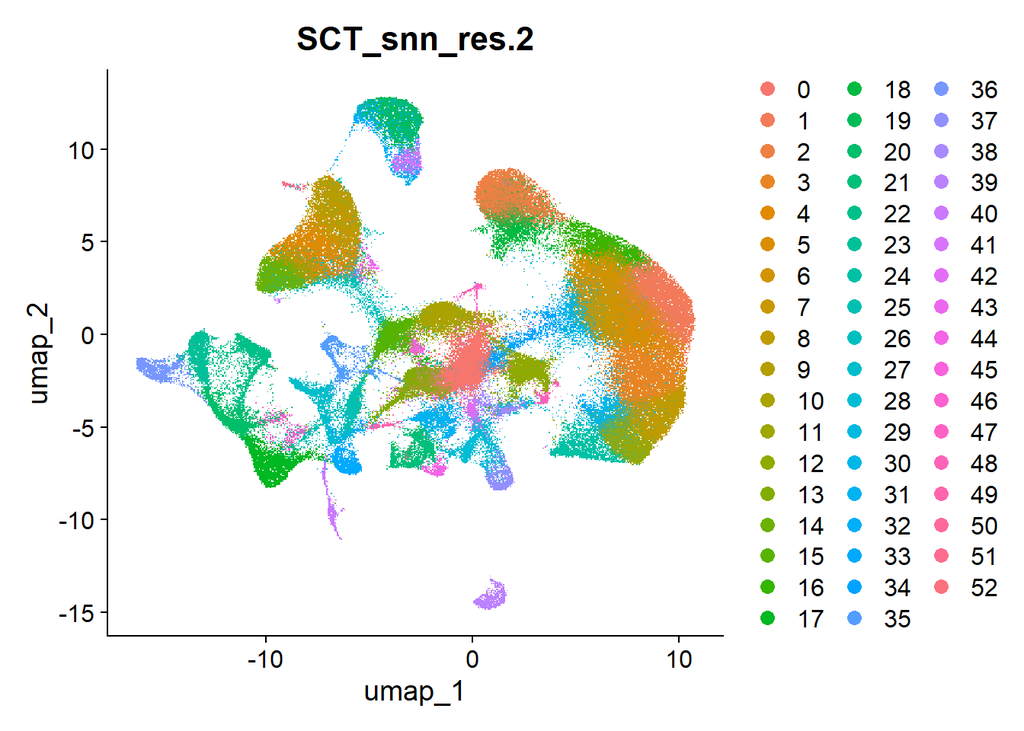

```r
xenium.obj <- qread(here("Week 8 Xenium Annotation", "region1_xenium.qs"))

DimPlot(xenium.obj, group.by = "SCT_snn_res.2")
```

## 4.3 Now What?!?!?

### 4.3.1 How do you **annotate** this object? What would you want to know **beforehand**?

### 4.3.2 Insight from snRNAseq analysis from **similar tissue**

#### 4.3.2.1 I’m **still suprised** at how similar this looks to a dissociated snRNAseq dataset

### 4.3.3 I started with what I knew about dissociated snRNaseq from this tissue

#### 4.3.3.1 Both from the literature and my own experience and background knowledge about the kidney

### 4.3.4 I applied my snRNaseq guide markers

https://usckrc.github.io/website/scRNAseq_guide.html

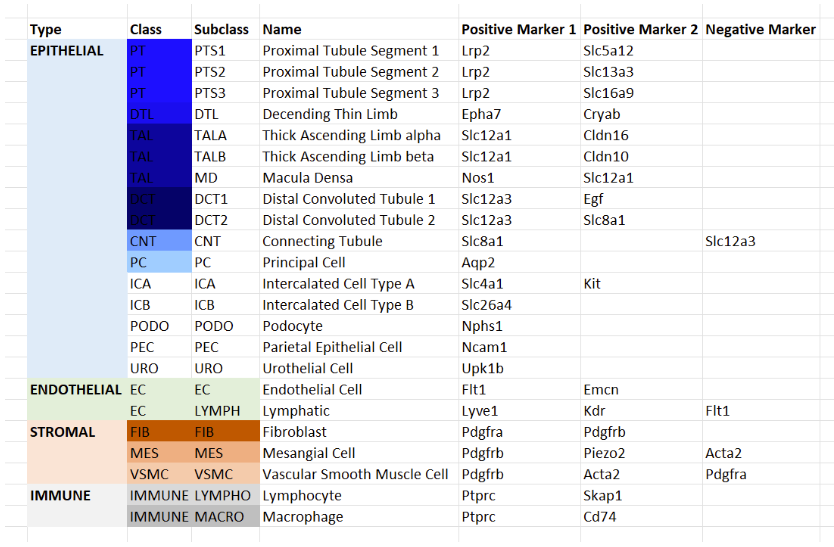

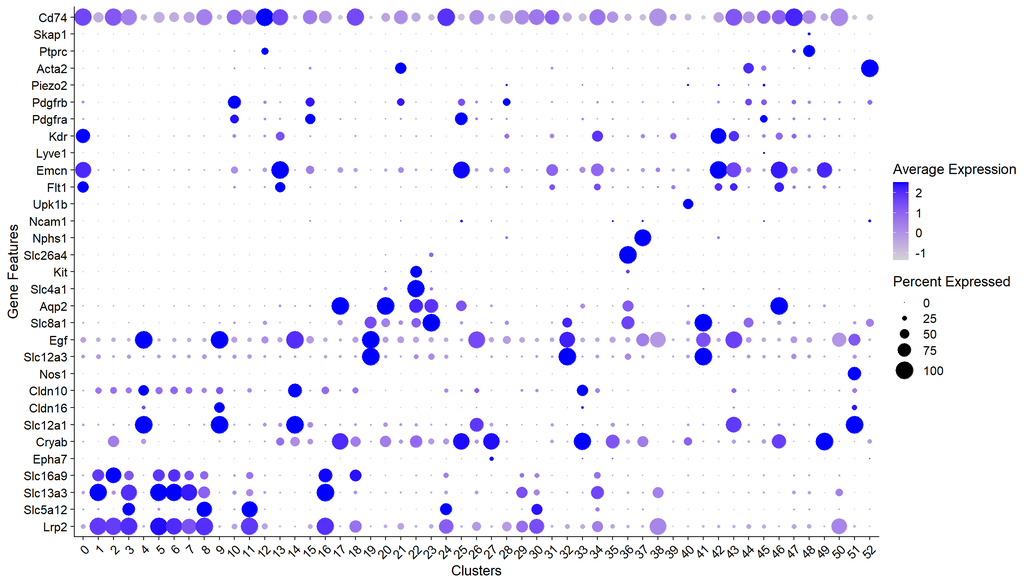

```r
markers.to.plot1 <- c("Lrp2",         # PTS1, PTS2, PTS3
                      "Slc5a12",      # PTS1
                      "Slc13a3",      # PTS2
                      "Slc16a9",      # PTS3
                      "Epha7",        # DTL
                      "Cryab",        # DTL
                      "Slc12a1",      # TALA, TALB, MD
                      "Cldn16",       # TALA
                      "Cldn10",       # TALB
                      "Nos1",         # MD
                      "Slc12a3",      # DCT1, DCT2
                      "Egf",          # DCT1
                      "Slc8a1",       # CNT, DCT2
                      "Aqp2",         # PC
                      "Slc4a1",       # ICA
                      "Kit",          # ICA
                      "Slc26a4",      # ICB
                      "Nphs1",        # PODO
                      "Ncam1",        # PEC
                      "Upk1b",        # URO
                      "Flt1",         # EC
                      "Emcn",         # EC
                      "Lyve1",        # LYMPH
                      "Kdr",          # LYMPH
                      "Pdgfra",       # FIB
                      "Pdgfrb",       # FIB, MES, VSMC
                      "Piezo2",       # MES
                      "Acta2",        # VSMC
                      "Ptprc",        # LYMPHO, MACRO
                      "Skap1",        # LYMPHO
                      "Cd74"          # MACRO
)

p1 <- DotPlot(xenium.obj,
features = markers.to.plot1,
dot.scale = 8,
dot.min = 0,
scale.max = 100,
scale.min = 0,
col.min = -2.5,
col.max = 2.5) +
  theme(axis.text.x = element_text(angle = 45, hjust = 1)) +
  coord_flip() +
  labs(x = "Gene Features", y = "Clusters")

p1
```

### 4.3.5 Annotation and Leveling

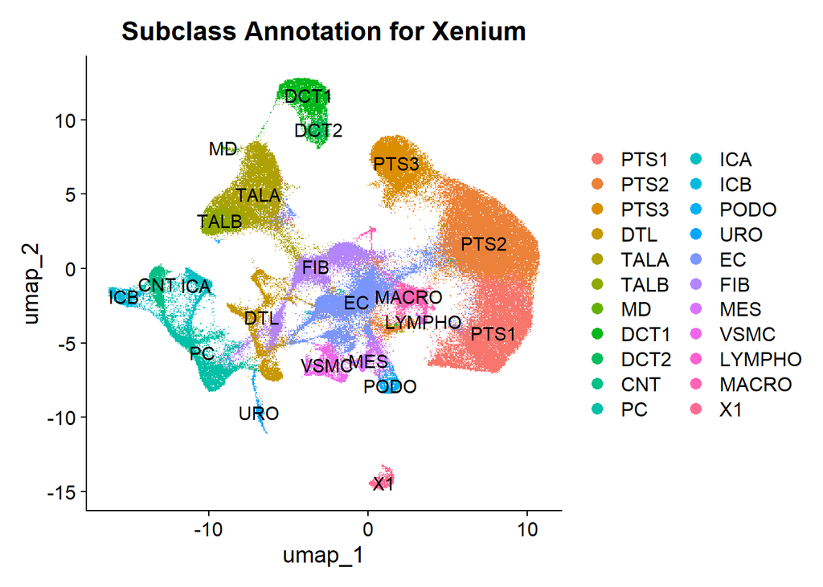

```r
xenium.obj@meta.data <- xenium.obj@meta.data %>%
  mutate(subclass = dplyr::case_when(
    seurat_clusters == 0  ~ "EC",
    seurat_clusters == 1  ~ "PTS2",
    seurat_clusters == 2  ~ "PTS3",
    seurat_clusters == 3  ~ "PTS1",
    seurat_clusters == 4  ~ "TALA",
    seurat_clusters == 5  ~ "PTS2",
    seurat_clusters == 6  ~ "PTS2",
    seurat_clusters == 7  ~ "PTS2",
    seurat_clusters == 8  ~ "PTS1",
    seurat_clusters == 9  ~ "TALA",
    seurat_clusters == 10 ~ "FIB",
    seurat_clusters == 11 ~ "PTS1",
    seurat_clusters == 12 ~ "MACRO",
    seurat_clusters == 13 ~ "EC",
    seurat_clusters == 14 ~ "TALB",
    seurat_clusters == 15 ~ "FIB",
    seurat_clusters == 16 ~ "PTS2",
    seurat_clusters == 17 ~ "PC",
    seurat_clusters == 18 ~ "PTS3",
    seurat_clusters == 19 ~ "DCT1",
    seurat_clusters == 20 ~ "PC",
    seurat_clusters == 21 ~ "VSMC",
    seurat_clusters == 22 ~ "ICA",
    seurat_clusters == 23 ~ "CNT",
    seurat_clusters == 24 ~ "PTS1",
    seurat_clusters == 25 ~ "FIB",
    seurat_clusters == 26 ~ "TALA",
    seurat_clusters == 27 ~ "DTL",
    seurat_clusters == 28 ~ "MES",
    seurat_clusters == 29 ~ "PTS2",
    seurat_clusters == 30 ~ "PTS1",
    seurat_clusters == 31 ~ "EC",
    seurat_clusters == 32 ~ "DCT1",
    seurat_clusters == 33 ~ "DTL",
    seurat_clusters == 34 ~ "EC",
    seurat_clusters == 35 ~ "DTL",
    seurat_clusters == 36 ~ "ICB",
    seurat_clusters == 37 ~ "PODO",
    seurat_clusters == 38 ~ "PTS2",
    seurat_clusters == 39 ~ "X1",
    seurat_clusters == 40 ~ "URO",
    seurat_clusters == 41 ~ "DCT2",
    seurat_clusters == 42 ~ "EC",
    seurat_clusters == 43 ~ "EC",
    seurat_clusters == 44 ~ "VSMC",
    seurat_clusters == 45 ~ "FIB",
    seurat_clusters == 46 ~ "PC",
    seurat_clusters == 47 ~ "MACRO",
    seurat_clusters == 48 ~ "LYMPHO",
    seurat_clusters == 49 ~ "EC",
    seurat_clusters == 50 ~ "PTS2",
    seurat_clusters == 51 ~ "MD",
    seurat_clusters == 52 ~ "VSMC",
    TRUE ~ NA_character_
  ))

subclass_order <- c("PTS1", "PTS2", "PTS3", "DTL", "TALA", "TALB", "MD", "DCT1", "DCT2", "CNT", "PC", "ICA", "ICB", "PODO", "PEC", "URO", "EC", "FIB", "MES", "VSMC", "LYMPHO", "MACRO", "X1")

xenium.obj@meta.data$subclass <- factor(xenium.obj@meta.data$subclass, levels = subclass_order)

# Change the identities to align with new subclass names and make umap

Idents(xenium.obj) <- xenium.obj@meta.data$subclass

DimPlot(xenium.obj, reduction = "umap", label = TRUE, label.size = 4) +
  theme(plot.title = element_text(hjust = 0.5)) +
  ggtitle(paste0("Subclass Annotation for Xenium"))
```

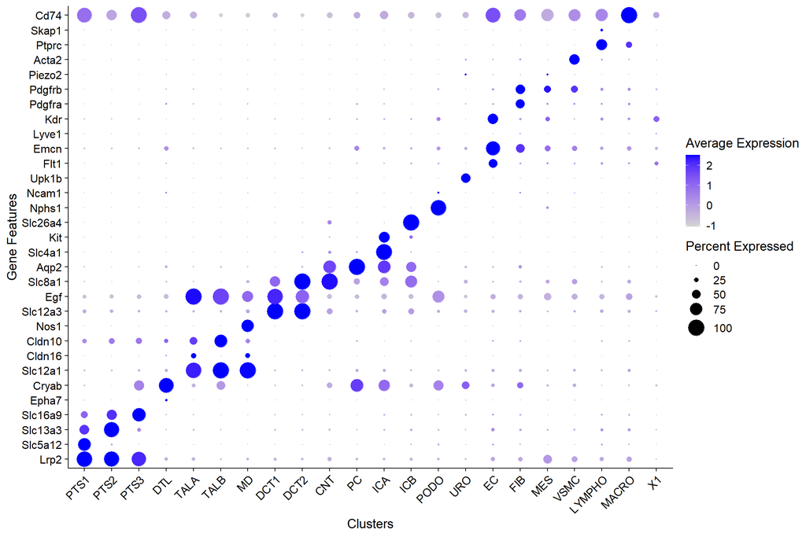

```r
p2 <- DotPlot(xenium.obj,
features = markers.to.plot1,
dot.scale = 8,
dot.min = 0,
scale.max = 100,
scale.min = 0,
col.min = -2.5,
col.max = 2.5) +
  theme(axis.text.x = element_text(angle = 45, hjust = 1)) +
  coord_flip() +
  labs(x = "Gene Features", y = "Clusters")

p2
```

## 4.4 Spatial vs. snRNAseq

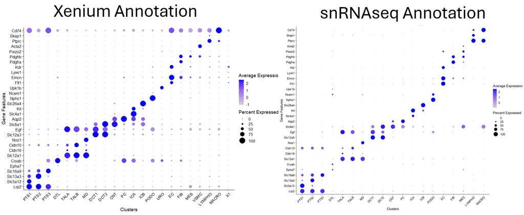

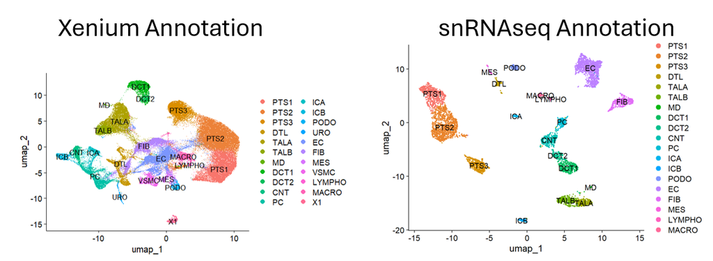

### 4.4.1 Looks pretty similar…Right?!?!?

## 4.5 Visulaizing Annotation on Tissue

```r
# Get cell IDs and cluster assignments
df_export <- data.frame(
  cell_id = Cells(xenium.obj),
  group   = xenium.obj@meta.data$subclass
) %>%
  tibble::rownames_to_column("row") %>%
  select(-row)

# Save as CSV
write.csv(df_export, "cellid_subclass_cluster_export.csv", row.names = FALSE)
```

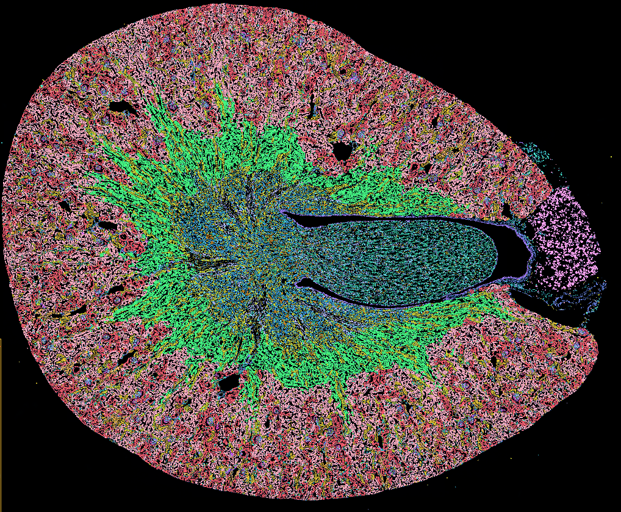

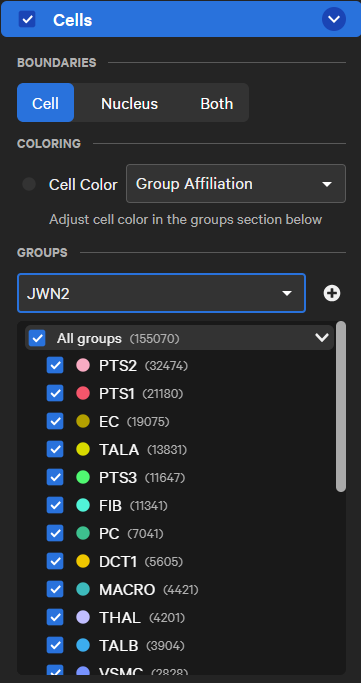

## 4.6 **Spatial Informed** Annotation

### 4.6.1 Is there **additional** information that we could get from the Xenium dataset?

### 4.6.2 Lessons from **Endothelial Cells**

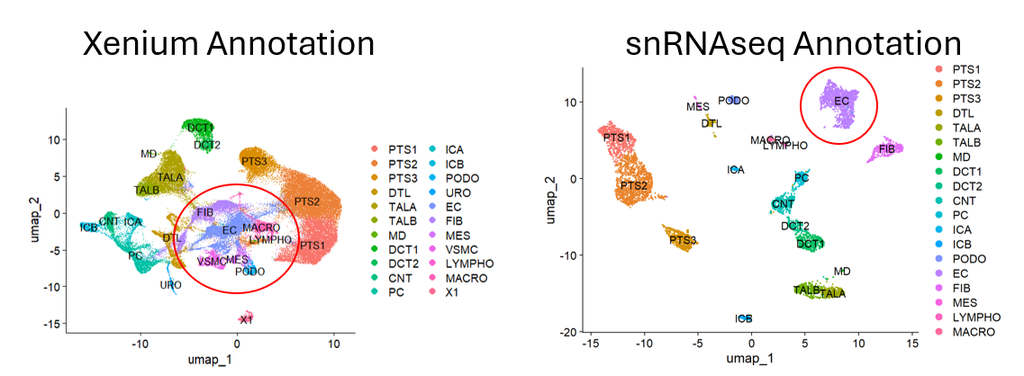

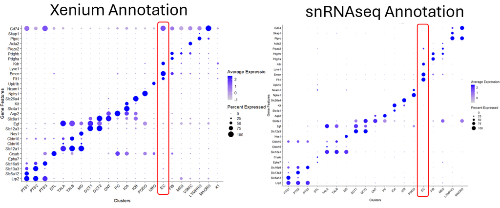

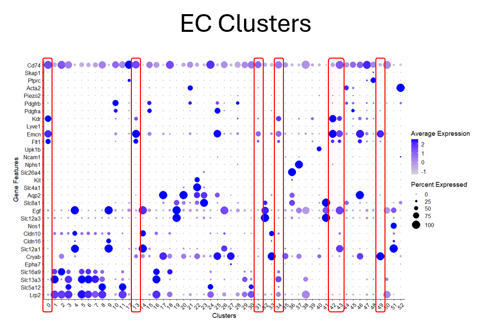

#### 4.6.2.1 EC Populations **within the Tissue**

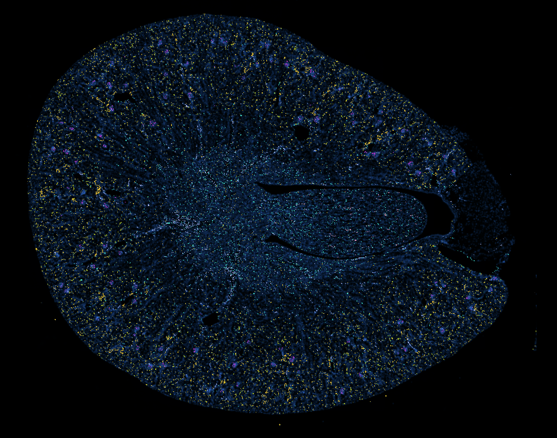

#### 4.6.2.2 **Clear** Spatial Distribution of EC Populations (**That Make Sense**)

##### 4.6.2.2.1 Cortical

##### 4.6.2.2.2 Medullary

##### 4.6.2.2.3 Glomerular

##### 4.6.2.2.4 Large Vessel

#### 4.6.2.3 Were these the **best markers** that I could be using for annotation?

#### 4.6.2.4 I went back to the **Res = 2** populations

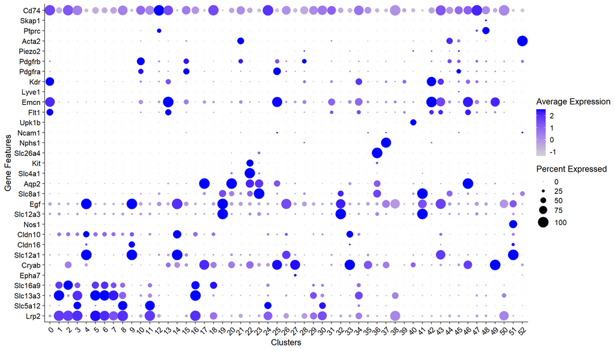

```r
p1
```

#### 4.6.2.5 Did **FindAllMarkers** and Analyzed the Top Markers for each cluster

```r
df <- FindAllMarkers(xenium.obj, only.pos = TRUE, min.pct = .25)

# Order by avg_log2FC
all_markers <- df %>%
  arrange(desc(avg_log2FC)) %>%
  select(gene, everything())

# Split by cluster (ident column)
marker_list <- split(all_markers, all_markers$cluster)

# Sort names alphanumerically
sorted_cluster_names <- names(marker_list)[order(as.numeric(names(marker_list)))]

# Create a workbook
wb <- createWorkbook()

# Add each cluster as a new worksheet
for (cluster_name in sorted_cluster_names) {
  addWorksheet(wb, sheetName = cluster_name)
  writeData(wb, sheet = cluster_name, marker_list[[cluster_name]])
}

date <- format(Sys.Date(), "%Y%m%d")

# Save workbook
saveWorkbook(wb, here(paste0(date, "_", "FindAllMarkers_By_Cluster.xlsx")), overwrite = TRUE)
```

#### 4.6.2.6 I asked: How far **down** the DEG list do I go before I find the identifying marker gene?

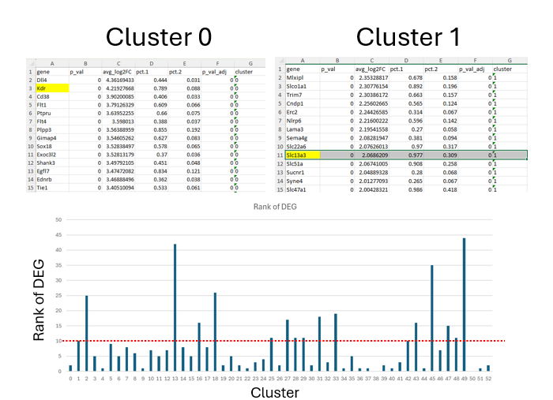

#### 4.6.2.7 Some clusters had better genes that I wasn’t using as **identifying markers**.

#### 4.6.2.8 Some clusters had **clear rare** population identities

##### 4.6.2.8.1 **Endothelial Cells**

##### 4.6.2.8.2 **Thin Ascending Limb**

##### 4.6.2.8.3 **Thin Decending Limb**

##### 4.6.2.8.4 **Renin Cells**

#### 4.6.2.9 What’s the **difference** for me in the Xenium Dataset

##### 4.6.2.9.1 Tiny clusters aren’t random (**by chance**)

##### 4.6.2.9.2 I can visually confirm their pattern within tissue

### 4.6.3 Currently work on creating a different **annotation guide** for **Xenium**

### 4.6.4 Need to go back to a snRNAseq dataset and see how well **Spatial Gene Marker List** works

## 4.7 Questions?

[figure not shown]

## 4.8 Community Questions

Do you have a **coding problem** that you’d like some support on?  
Do you have a **topic** you’d like covered at a future meeting?

Email me: **j.nelson@med.usc.edu**

## 4.9 Upcoming Schedule

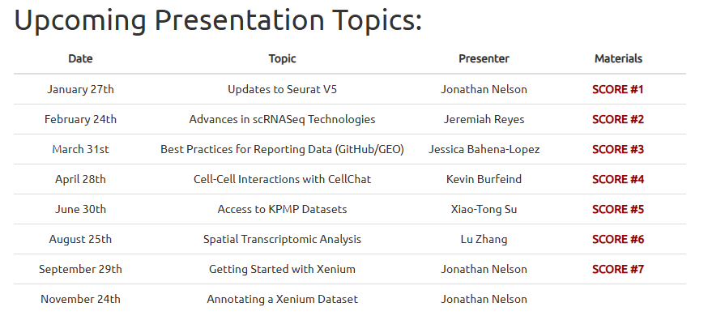

## 4.10 Brainstorming Upcoming Topics

### 4.10.1 Potential Future Topics on Xenium Analysis

#### 4.10.1.1 **Spatial Cell Segmentation Algorithms**

#### 4.10.1.2 **Label Transfer between snRNAseq and Xenium**

#### 4.10.1.3 Integration of Xenium and snRNAseq Datasets

#### 4.10.1.4 Comparing Xenium and snRNAseq DEG Analysis